# CENG 4515 DATA SCIENCE AND ANALYTICS-HW3

İrem Uslu

## Importing libraries

```r
  library(dplyr)
  library(plyr)
  library(caret)
  library(factoextra)
  library(skimr)
  library(RANN)
  library(cluster)
  library(mice)
  library(randomForest)
  library(klaR)
  library(e1071)
```

### Dowload the “mole2_dataset.csv”.

```r
mole <- read.csv("mole2_dataset.csv" , header=TRUE , sep=",")
mole$diagnosis <-  factor(mole$diagnosis)
mole$sex <- NULL
mole$X <- NULL
mole$image_id <- NULL
```

### 1-) The data were splitted into 80% train and 20% test.

```r
set.seed(200)
trainIndex <- createDataPartition(mole$diagnosis, p = .8,
                                  list = FALSE)
train <- mole[trainIndex, ]
test <- mole[-trainIndex, ]

x = train[, 1:10]
y = train$diagnosis
```

### 2-) Used skim_to_wide function in skimr package.

```r
skimmed <- skim_to_wide(train)
skimmed
```

Data summary

| Name | Piped data |
| --- | --- |
| Number of rows | 321 |
| Number of columns | 11 |
| _______________________ |  |
| Column type frequency: |  |
| factor | 1 |
| numeric | 10 |
| ________________________ |  |
| Group variables | None |

**Variable type: factor**

| skim_variable | n_missing | complete_rate | ordered | n_unique | top_counts |
| --- | --- | --- | --- | --- | --- |
| diagnosis | 0 | 1 | FALSE | 4 | mel: 156, nev: 114, seb: 47, bas: 4 |

**Variable type: numeric**

| skim_variable | n_missing | complete_rate | mean | sd | p0 | p25 | p50 | p75 | p100 | hist |
| --- | --- | --- | --- | --- | --- | --- | --- | --- | --- | --- |
| pixels_x | 0 | 1.00 | 2349.98 | 1162.48 | 640.00 | 1024.00 | 2014.00 | 3264.00 | 6000.00 | ▆▅▇▁▁ |
| pixels_y | 0 | 1.00 | 1767.88 | 788.21 | 480.00 | 1024.00 | 1936.00 | 2448.00 | 4000.00 | ▇▁▇▁▁ |
| clin_size_long_diam_mm | 213 | 0.34 | 6.60 | 4.12 | 1.60 | 3.70 | 5.20 | 7.72 | 19.30 | ▇▅▂▁▁ |
| full_img_size | 0 | 1.00 | 337612.92 | 273112.07 | 24653.00 | 84819.00 | 341310.00 | 537615.00 | 1907816.00 | ▇▆▁▁▁ |
| age_approx | 1 | 1.00 | 58.08 | 16.17 | 10.00 | 45.00 | 60.00 | 70.00 | 85.00 | ▁▅▇▇▆ |
| non_overlapping_rate | 0 | 1.00 | 114.49 | 62.22 | 0.00 | 56.83 | 120.16 | 170.85 | 200.00 | ▃▆▅▆▇ |
| corners | 0 | 1.00 | 136.93 | 265.52 | 0.00 | 32.00 | 65.00 | 126.00 | 2280.00 | ▇▁▁▁▁ |
| red | 17 | 0.95 | 156.32 | 49.69 | 2.45 | 130.67 | 168.63 | 196.13 | 235.49 | ▁▂▅▇▇ |
| green | 17 | 0.95 | 110.92 | 48.32 | 2.45 | 73.74 | 117.53 | 151.77 | 223.03 | ▂▅▆▇▁ |
| blue | 17 | 0.95 | 99.63 | 48.04 | 2.45 | 59.46 | 101.72 | 138.23 | 213.76 | ▅▇▇▇▂ |

### 3-) Missing values were predicted and imputed.

```r
#KNN Imputation
preProcessModel <- preProcess(train, method='knnImpute')
preProcessModel
```

```
## Created from 108 samples and 11 variables
##
## Pre-processing:
##   - centered (10)
##   - ignored (1)
##   - 5 nearest neighbor imputation (10)
##   - scaled (10)
```

```r
#Imputation model was used to predict the values of missing data points.
train <- predict(preProcessModel, newdata = train)

#KNN Imputation for test set
preProcessModelTest <- preProcess(test, method='knnImpute')
preProcessModelTest
```

```
## Created from 28 samples and 11 variables
##
## Pre-processing:
##   - centered (10)
##   - ignored (1)
##   - 5 nearest neighbor imputation (10)
##   - scaled (10)
```

```r
#Imputation model was used to predict the values of missing data points for test set.
test <- predict(preProcessModelTest, newdata = test)
```

As a result of KNN imputation, 10 variables were centered, 1 of them were ignored. For the predict of missing values, k was taken as 5 and 10 variables were scaled.And then all the missing values are loaded.

### 4-) All numerical variables were transformed with the preprocess function by setting them between 0 and 1.

```r
preProcess_range_model <- preProcess(train, method='range')
train <- predict(preProcess_range_model, newdata = train)
head(train,5)
```

```
##     pixels_x  pixels_y clin_size_long_diam_mm full_img_size age_approx
## 1 0.48955224 0.5590909             0.27118644    0.27239384  0.6000000
## 2 0.48955224 0.5590909             0.18079096    0.25872110  0.5333333
## 4 0.48955224 0.5590909             0.03954802    0.18474450  0.4000000
## 5 0.48955224 0.5590909             0.29943503    0.25822406  0.8000000
## 6 0.07164179 0.1545455             0.30282486    0.02851161  0.8000000
##   non_overlapping_rate     corners       red     green      blue
## 1            0.3499302 0.052192982 0.7914071 0.6380251 0.5791780
## 2            0.9999780 0.009649123 0.8193182 0.7021970 0.7616622
## 4            0.0000000 0.000000000 1.0000000 1.0000000 1.0000000
## 5            0.9974519 0.001754386 0.8912748 0.7191407 0.7383297
## 6            0.6265589 0.019736842 0.8098176 0.7299132 0.7296505
##              diagnosis
## 1                nevus
## 2                nevus
## 4                nevus
## 5 seborrheic keratosis
## 6             melanoma
```

```r
train$diagnosis <- y
apply(train[, c(1:10)], 2, FUN=function(x){c('min'=min(x), 'max'=max(x))})
```

```
##     pixels_x pixels_y clin_size_long_diam_mm full_img_size age_approx
## min        0        0                      0             0          0
## max        1        1                      1             1          1
##     non_overlapping_rate corners red green blue
## min                    0       0   0     0    0
## max                    1       1   1     1    1
```

### 5-)Use caret’s featurePlot() function to visually.

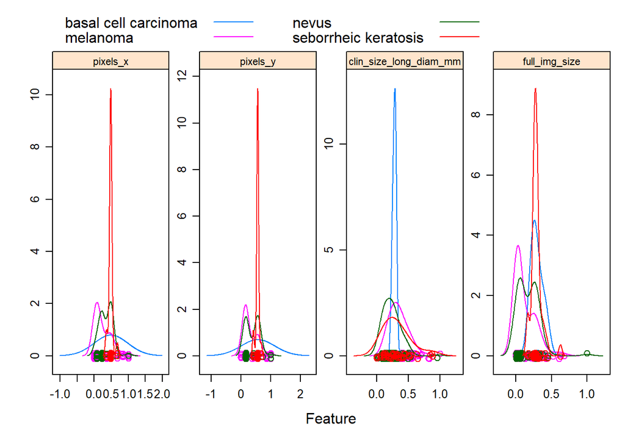

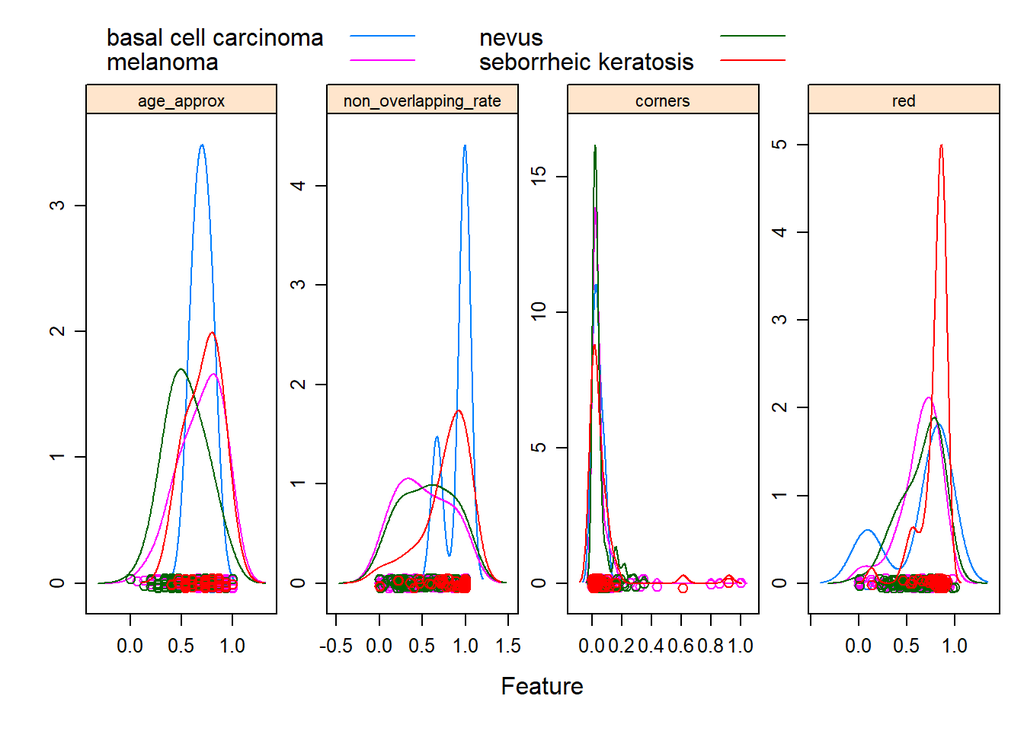

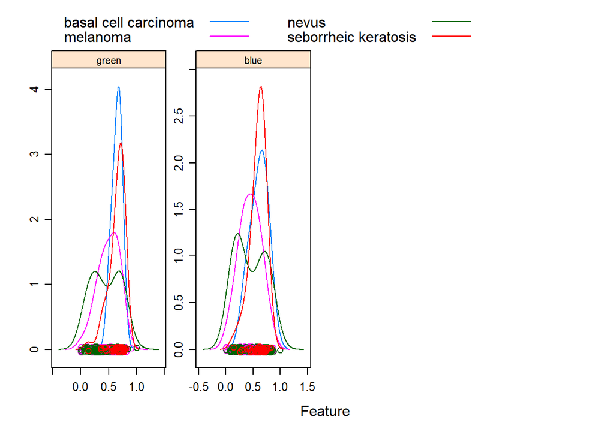

```r
featurePlot(x = train[, c(1:10)],
            y = train$diagnosis,
            plot = "density",
            strip=strip.custom(par.strip.text=list(cex=.7)),
            auto.key = list(columns = 3),
            adjust = 1.5,
            layout = c(4,1),
            scales = list(x = list(relation="free"),
                          y = list(relation="free")))
```

In order to understand whether a variable is important or not, we expect the density curves to be different from each other in terms of both kurtosis and skewness for the 4 classes.It can be said that the red, blue, green variables are important for the disease independent variable.But we can’t say that it is very important for the corners variable because the values for all 4 variables are very similar.

### 6-)

#### a)Use train() function to build the machine learning model. Choose knn algorithm.

```r
trctrl <- trainControl(method = "repeatedcv", number = 10, repeats = 3)
set.seed(100)

knn_fit <- train(diagnosis ~ . , data = train, method = "knn",
 trControl=trctrl,
 preProcess = c("center", "scale"),
 tuneLength = 10)

knn_fit
```

```
## k-Nearest Neighbors
##
## 321 samples
##  10 predictor
##   4 classes: 'basal cell carcinoma', 'melanoma', 'nevus', 'seborrheic keratosis'
##
## Pre-processing: centered (10), scaled (10)
## Resampling: Cross-Validated (10 fold, repeated 3 times)
## Summary of sample sizes: 288, 288, 288, 288, 289, 290, ...
## Resampling results across tuning parameters:
##
##   k   Accuracy   Kappa
##    5  0.6330972  0.4040561
##    7  0.6523560  0.4292906
##    9  0.6440444  0.4138020
##   11  0.6473987  0.4134898
##   13  0.6389348  0.3956797
##   15  0.6388062  0.3958292
##   17  0.6420477  0.4012893
##   19  0.6359220  0.3913483
##   21  0.6402863  0.3987703
##   23  0.6356990  0.3919615
##
## Accuracy was used to select the optimal model using the largest value.
## The final value used for the model was k = 7.
```

7 is chosen as the best k value.

#### b)Make predictions for test data using the predict() function.

```r
predicted <- predict(knn_fit, test)
head(predicted)
```

```
## [1] melanoma             nevus                melanoma
## [4] melanoma             nevus                seborrheic keratosis
## Levels: basal cell carcinoma melanoma nevus seborrheic keratosis
```

#### c)Construct the confusion matrix to compare the predictions (data) vs the actuals (reference).

```r
confusionMatrix(reference = test$diagnosis, data = predicted)
```

```
## Confusion Matrix and Statistics
##
##                       Reference
## Prediction             basal cell carcinoma melanoma nevus seborrheic keratosis
##   basal cell carcinoma                    0        0     0                    0
##   melanoma                                1       34    12                    2
##   nevus                                   0        2    14                    4
##   seborrheic keratosis                    0        3     2                    5
##
## Overall Statistics
##
##                Accuracy : 0.6709
##                  95% CI : (0.556, 0.7725)
##     No Information Rate : 0.4937
##     P-Value [Acc > NIR] : 0.001102
##
##                   Kappa : 0.4388
##
##  Mcnemar's Test P-Value : NA
##
## Statistics by Class:
##
##                      Class: basal cell carcinoma Class: melanoma Class: nevus
## Sensitivity                              0.00000          0.8718       0.5000
## Specificity                              1.00000          0.6250       0.8824
## Pos Pred Value                               NaN          0.6939       0.7000
## Neg Pred Value                           0.98734          0.8333       0.7627
## Prevalence                               0.01266          0.4937       0.3544
## Detection Rate                           0.00000          0.4304       0.1772
## Detection Prevalence                     0.00000          0.6203       0.2532
## Balanced Accuracy                        0.50000          0.7484       0.6912
##                      Class: seborrheic keratosis
## Sensitivity                              0.45455
## Specificity                              0.92647
## Pos Pred Value                           0.50000
## Neg Pred Value                           0.91304
## Prevalence                               0.13924
## Detection Rate                           0.06329
## Detection Prevalence                     0.12658
## Balanced Accuracy                        0.69051
```

We view the statistics of our results with the confusion matrix. It shows that our model accuracy for the test set is 67.09%. It can take values between 56% and 77% with a 95% confidence interval.

### 7-)

#### a)Use train() function to build the machine learning model. Choose random forest algorithm.

```r
set.seed(100)

modelLookup("rf")
```

```
##   model parameter                         label forReg forClass probModel
## 1    rf      mtry #Randomly Selected Predictors   TRUE     TRUE      TRUE
```

```r
trControlRF <- trainControl(method = "repeatedcv" , number = 5,
                            repeats=3,
                            search = "random")

modelRFTune <- train(diagnosis~. , data = train,
                     method = "rf",
                     tuneLength = 20,
                     trControl = trControlRF)

modelRFTune
```

```
## Random Forest
##
## 321 samples
##  10 predictor
##   4 classes: 'basal cell carcinoma', 'melanoma', 'nevus', 'seborrheic keratosis'
##
## No pre-processing
## Resampling: Cross-Validated (5 fold, repeated 3 times)
## Summary of sample sizes: 256, 257, 256, 257, 258, 256, ...
## Resampling results across tuning parameters:
##
##   mtry  Accuracy   Kappa
##    2    0.6823236  0.4734254
##    3    0.6761853  0.4668142
##    4    0.6750464  0.4639246
##    6    0.6626070  0.4429765
##    7    0.6678168  0.4520431
##    8    0.6731234  0.4600710
##    9    0.6636977  0.4436469
##   10    0.6656011  0.4473901
##
## Accuracy was used to select the optimal model using the largest value.
## The final value used for the model was mtry = 2.
```

#### b)Make predictions for test data using the predict() function.

```r
predictedRFTune<-predict(modelRFTune$finalModel , test)
head(predictedRFTune)
```

```
##        3       10       13       30       36       43
## melanoma    nevus melanoma melanoma    nevus    nevus
## Levels: basal cell carcinoma melanoma nevus seborrheic keratosis
```

#### c)Construct the confusion matrix to compare the predictions (data) vs the actuals (reference).

```r
confusionMatrix(reference = test$diagnosis, data = predictedRFTune)
```

```
## Confusion Matrix and Statistics
##
##                       Reference
## Prediction             basal cell carcinoma melanoma nevus seborrheic keratosis
##   basal cell carcinoma                    0        0     0                    0
##   melanoma                                0       34    11                    5
##   nevus                                   1        4    16                    5
##   seborrheic keratosis                    0        1     1                    1
##
## Overall Statistics
##
##                Accuracy : 0.6456
##                  95% CI : (0.5299, 0.75)
##     No Information Rate : 0.4937
##     P-Value [Acc > NIR] : 0.004646
##
##                   Kappa : 0.3734
##
##  Mcnemar's Test P-Value : NA
##
## Statistics by Class:
##
##                      Class: basal cell carcinoma Class: melanoma Class: nevus
## Sensitivity                              0.00000          0.8718       0.5714
## Specificity                              1.00000          0.6000       0.8039
## Pos Pred Value                               NaN          0.6800       0.6154
## Neg Pred Value                           0.98734          0.8276       0.7736
## Prevalence                               0.01266          0.4937       0.3544
## Detection Rate                           0.00000          0.4304       0.2025
## Detection Prevalence                     0.00000          0.6329       0.3291
## Balanced Accuracy                        0.50000          0.7359       0.6877
##                      Class: seborrheic keratosis
## Sensitivity                              0.09091
## Specificity                              0.97059
## Pos Pred Value                           0.33333
## Neg Pred Value                           0.86842
## Prevalence                               0.13924
## Detection Rate                           0.01266
## Detection Prevalence                     0.03797
## Balanced Accuracy                        0.53075
```

We view the statistics of our results with the confusion matrix. It shows that our model accuracy for the test set is 64.6%. It can take values between 53% and 75% with a 95% confidence interval.Actual values and predicted values are not very similar to each other because the kappa value is low.

### 8-)

#### a)Use train() function to build the machine learning model. Choose naïve bayes classification algorithm.

```r
set.seed(100)
modelNB <- train(diagnosis ~ .,
                               data = train,
                               method = "naive_bayes",
                               usepoisson = TRUE)

modelNB
```

```
## Naive Bayes
##
## 321 samples
##  10 predictor
##   4 classes: 'basal cell carcinoma', 'melanoma', 'nevus', 'seborrheic keratosis'
##
## No pre-processing
## Resampling: Bootstrapped (25 reps)
## Summary of sample sizes: 321, 321, 321, 321, 321, 321, ...
## Resampling results across tuning parameters:
##
##   usekernel  Accuracy   Kappa
##   FALSE      0.5113037  0.2764476
##    TRUE      0.5544265  0.3363215
##
## Tuning parameter 'laplace' was held constant at a value of 0
## Tuning
##  parameter 'adjust' was held constant at a value of 1
## Accuracy was used to select the optimal model using the largest value.
## The final values used for the model were laplace = 0, usekernel = TRUE
##  and adjust = 1.
```

#### b)Make predictions for test data using the predict() function.

```r
predictedNB<-predict(modelNB$finalModel , test)
head(predictedNB)
```

```
## [1] basal cell carcinoma basal cell carcinoma basal cell carcinoma
## [4] basal cell carcinoma basal cell carcinoma melanoma
## Levels: basal cell carcinoma melanoma nevus seborrheic keratosis
```

#### c)Construct the confusion matrix to compare the predictions (data) vs the actuals (reference).

```r
nb_cm <- confusionMatrix(test$diagnosis , predictedNB)
nb_cm
```

```
## Confusion Matrix and Statistics
##
##                       Reference
## Prediction             basal cell carcinoma melanoma nevus seborrheic keratosis
##   basal cell carcinoma                    1        0     0                    0
##   melanoma                               32        1     4                    2
##   nevus                                  24        3     1                    0
##   seborrheic keratosis                    8        2     1                    0
##
## Overall Statistics
##
##                Accuracy : 0.038
##                  95% CI : (0.0079, 0.107)
##     No Information Rate : 0.8228
##     P-Value [Acc > NIR] : 1
##
##                   Kappa : -0.0438
##
##  Mcnemar's Test P-Value : 4.034e-12
##
## Statistics by Class:
##
##                      Class: basal cell carcinoma Class: melanoma Class: nevus
## Sensitivity                              0.01538         0.16667      0.16667
## Specificity                              1.00000         0.47945      0.63014
## Pos Pred Value                           1.00000         0.02564      0.03571
## Neg Pred Value                           0.17949         0.87500      0.90196
## Prevalence                               0.82278         0.07595      0.07595
## Detection Rate                           0.01266         0.01266      0.01266
## Detection Prevalence                     0.01266         0.49367      0.35443
## Balanced Accuracy                        0.50769         0.32306      0.39840
##                      Class: seborrheic keratosis
## Sensitivity                              0.00000
## Specificity                              0.85714
## Pos Pred Value                           0.00000
## Neg Pred Value                           0.97059
## Prevalence                               0.02532
## Detection Rate                           0.00000
## Detection Prevalence                     0.13924
## Balanced Accuracy                        0.42857
```

When we apply naive bayes, the accuracy value is quite low. Therefore, it is very difficult to make a successful prediction. The Kappa value is a negative value, so it cannot be said that the actual values and the predicted values are similar to each other.

### 9-) Compare and make more and more comments about the final results you find in steps “6-8”.

The accuracy rate in the KNN algorithm is quite high compared to naive bayes. Therefore, our model accuracy for our test set with the knn algorithm model is higher. Likewise, the kappa ratio is higher in the knn algorithm model. Therefore, the actual values and the predicted values are more similar to each other in the knn algorithm.